# Lab 02

Ryleigh Landstra

2022-11-13

# Evaluating Tree Height in Nichols Arboretum, Ann Arbor, Michigan

**Read in libraries**

```r
library(sf)
library(raster)
library(rgdal)
library(raster)
library(tmap)
library(tmaptools)
library(lidR)
library(RStoolbox)
library(ForestTools)
library(ggplot2)
library(rayshader)
library(rayrender)
```

```r
ctg <- readLAScatalog("C:/Users/rylan/Desktop/EAS 648/Lab02/Data/ArbLAS")
dsm <- grid_canopy(ctg, res = 10, pitfree(c(0,2,5,10,15), c(0, 1)))
```

```r
dtm <- grid_terrain(ctg, res = 10, algorithm = kriging(k = 40))
```

```r
chm <- dsm - dtm
chm_df <- as.data.frame(chm, xy = TRUE)
```

**Create 2D and 3D visual of the arboretum**  
*We can use the rayshader package to visualize the 4 combined tiles.*

```r
elmat <- raster_to_matrix(dsm)
```

```
#> [1] "Dimensions of matrix are: 284x284."
```

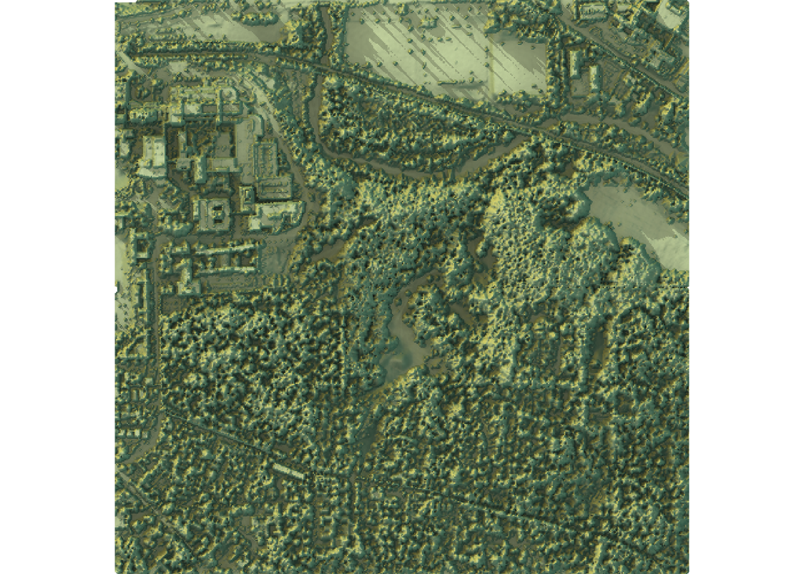

```r
map <- elmat %>%
  sphere_shade(texture = "imhof1", progbar = FALSE) %>%
  add_water(detect_water(elmat), color = "imhof1") %>%
  add_shadow(ray_shade(elmat, progbar = FALSE), 0.5) %>%
  add_shadow(ambient_shade(elmat, progbar = FALSE), 0)
plot_map(map)
```

```r
plot_3d(map, elmat, zscale = 5, windowsize = c(800, 800))
```

**Plot the DTM, DSM, and CHM**  
*We can plot these layers individually to compare the bare earth to the surface model, and visualize the resulting difference between the two.*

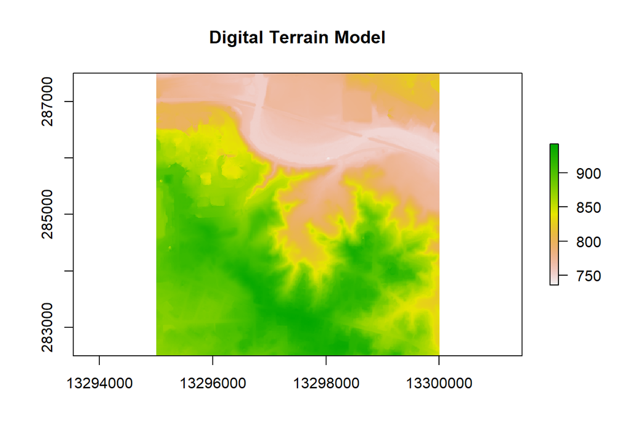

```r
plot(dtm, main="Digital Terrain Model")
```

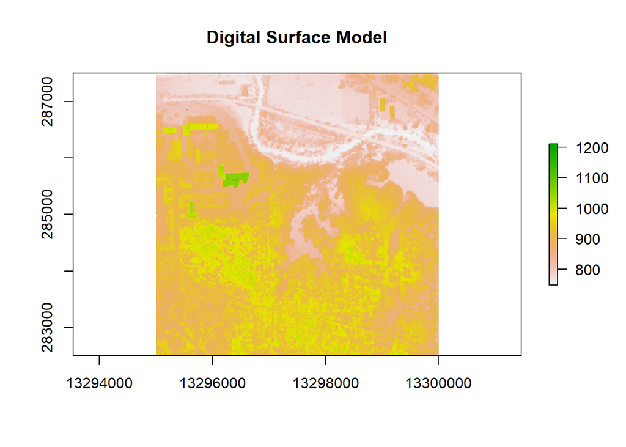

```r
plot(dsm,  main="Digital Surface Model")
```

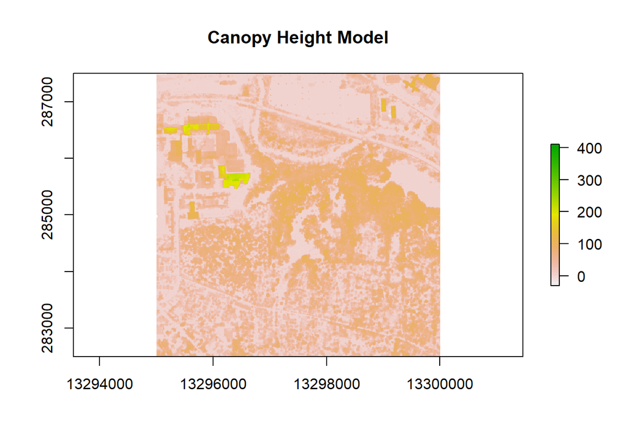

```r
plot(chm, main="Canopy Height Model")
```

*Here we can see the chm does not do an adequate job visualizing the trees in particular. This is due to the nearby buildings that skew the results of the chm calculation.*  
**Create new object to better visualize the tree canopy height of the area**  
*Here we can set a minimum and maximum for the chm layer. Since there are just a few buildings that are skewing the value range, we can set the maximum height to an approximation of the values in the chm plot (here I chose 150 as the maximum, as the buildings appear above 200).*

```r
min <- 1
max <- 150
```

**Plot the chm layer with new maximum**  
*Here we create the object chm2, apply the maximum and minimum, and plot the results to better visualize the tree canopy heights.*

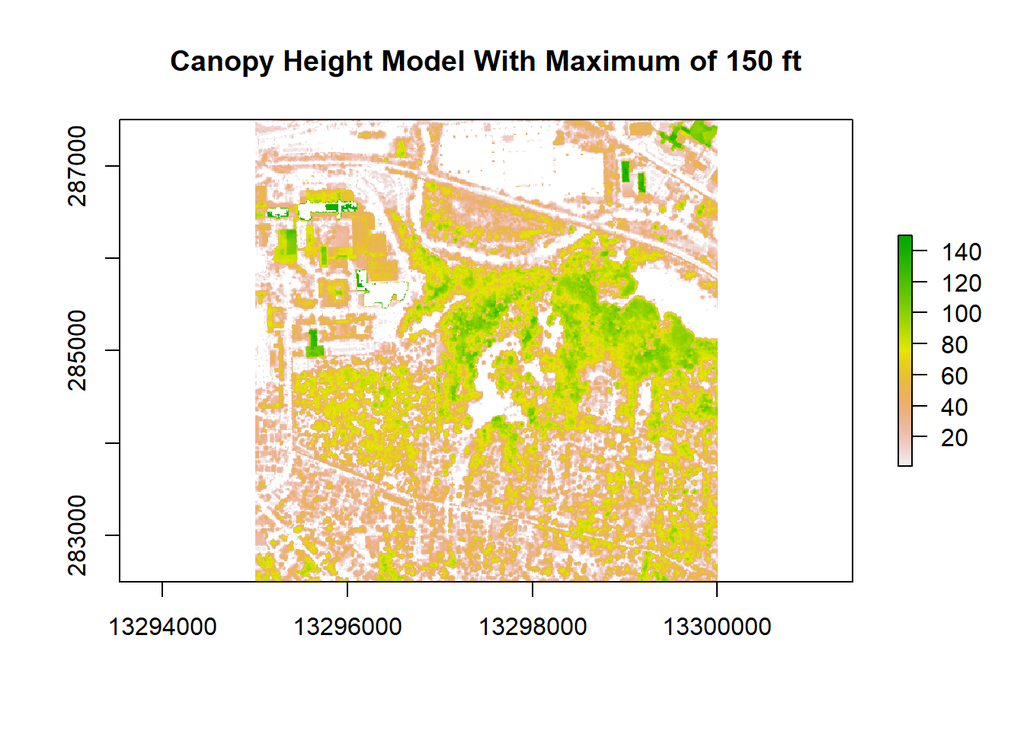

```r
chm2 <- chm
chm2[chm <= min] <- NA
chm2[chm >= max] <- NA
plot(chm2, main="Canopy Height Model With Maximum of 150 ft")
```

*Here we can more clearly see the canopy height of the trees within the arboretum. Comparing this plot the the original chm plot, we can see that the area with dark green values corresponds with the darker red areas above, but with more color variation that emphasize the tree heights*  
**Plot Canopy Height**  
*Here we can take the chm2 layer (with maximum and minimum) to gain a better understanding of the tree heights in the arboretum.*

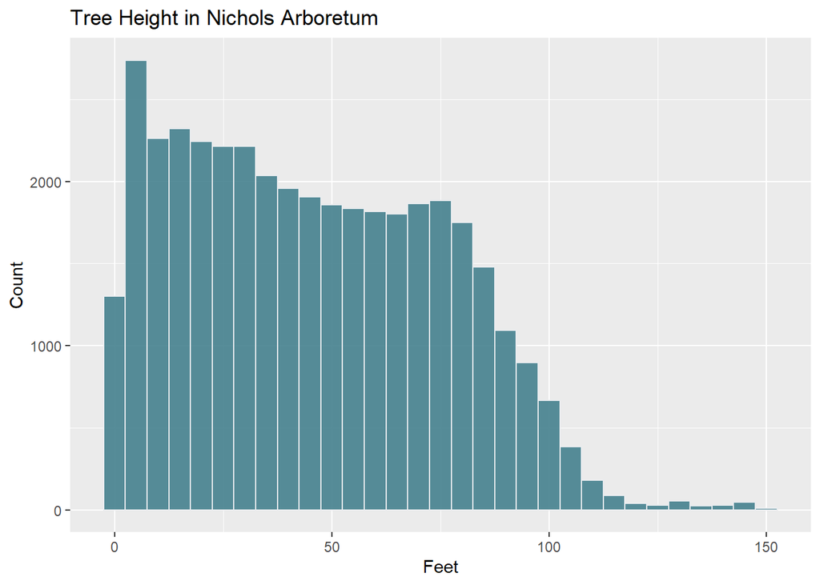

```r
ggplot(chm2) +
  geom_histogram(aes(layer), binwidth=5, fill="#45818e", color="#e9ecef", alpha=0.9) +
  ggtitle("Tree Height in Nichols Arboretum") +
  labs(y="Count", x="Feet")
```

*Since this analysis is conducted in an area that is not entirely forested, the tree height plot will inherently include other objects that are within the maximum and minimum range.*